# 02-Grafikoetarako

## Motak

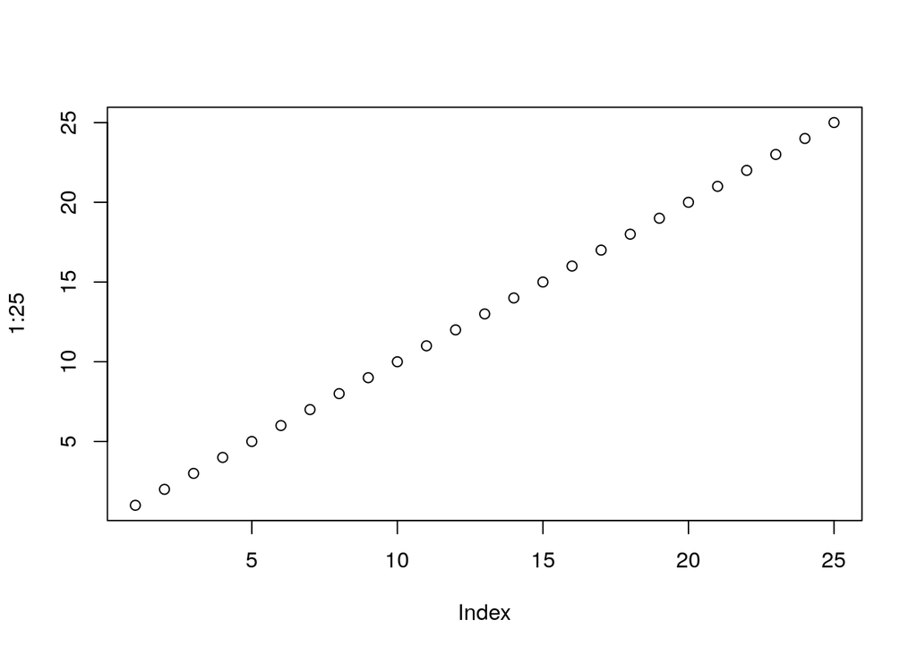

```r
# par(mfrow = c(2, 2))
plot(1:25, type = 'p')
```

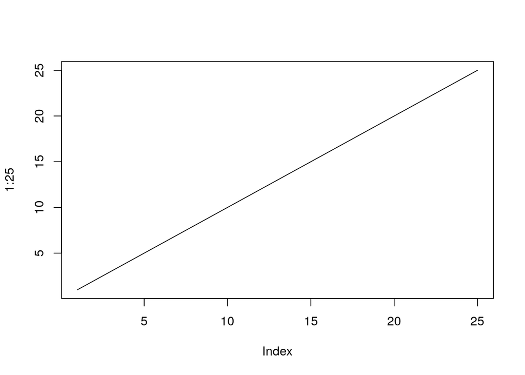

```r
plot(1:25, type = 'l')
```

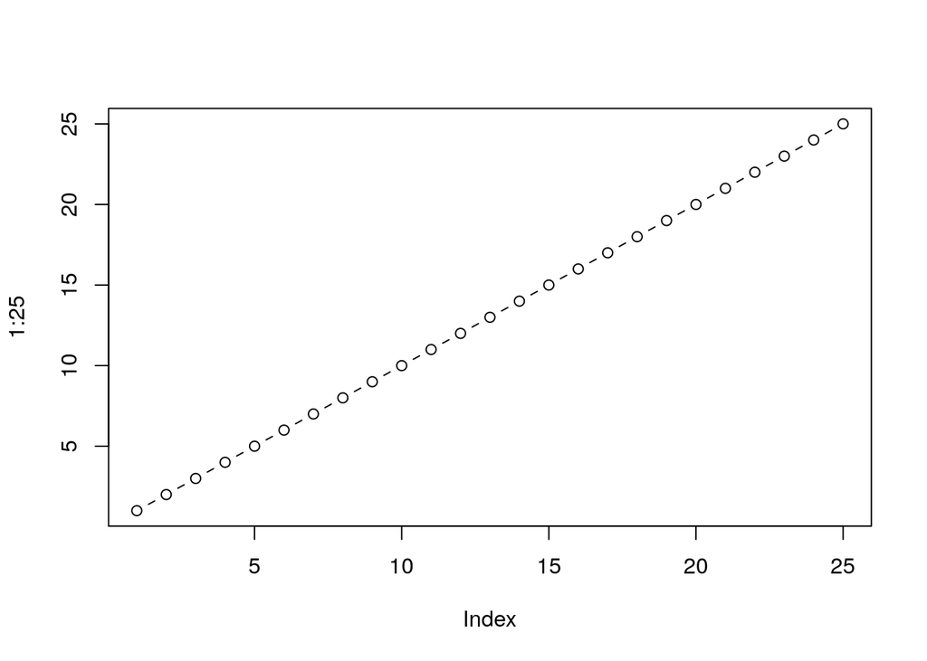

```r
plot(1:25, type = 'b')
```

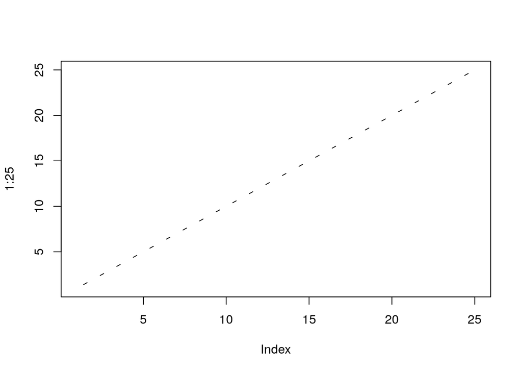

```r
plot(1:25, type = 'c')
```

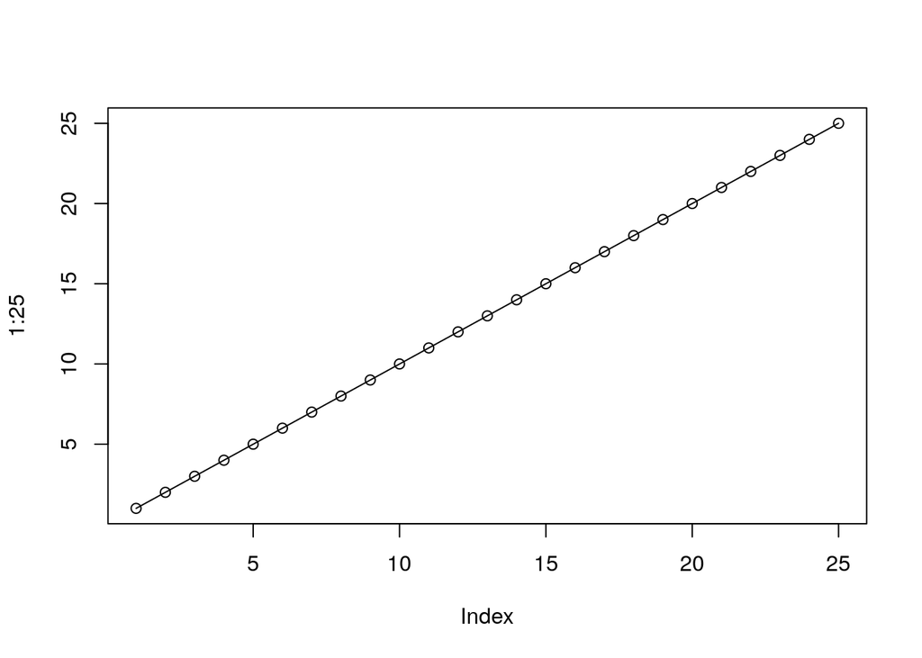

```r
plot(1:25, type = 'o')
```

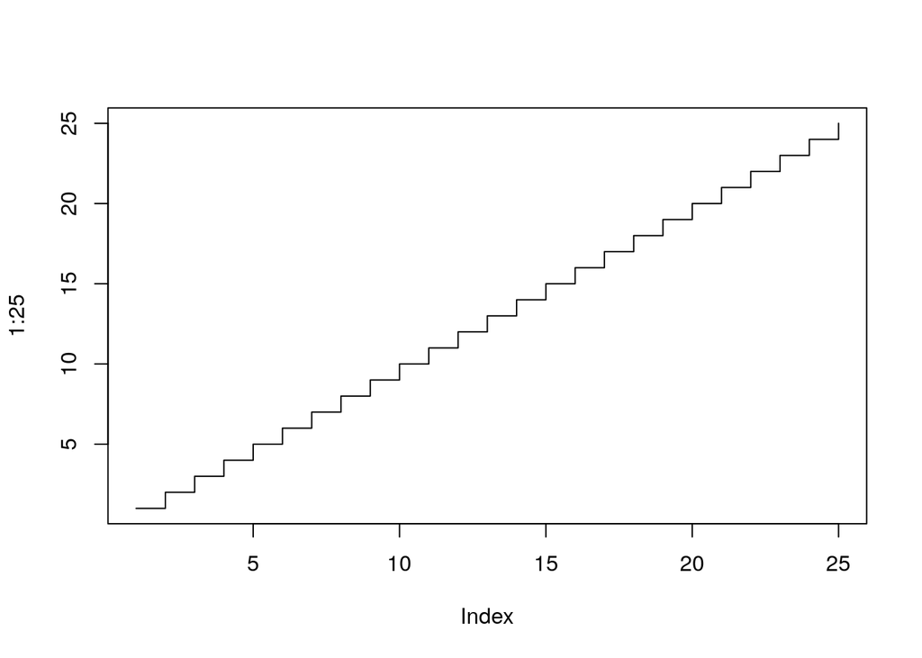

```r
plot(1:25, type = 's')
```

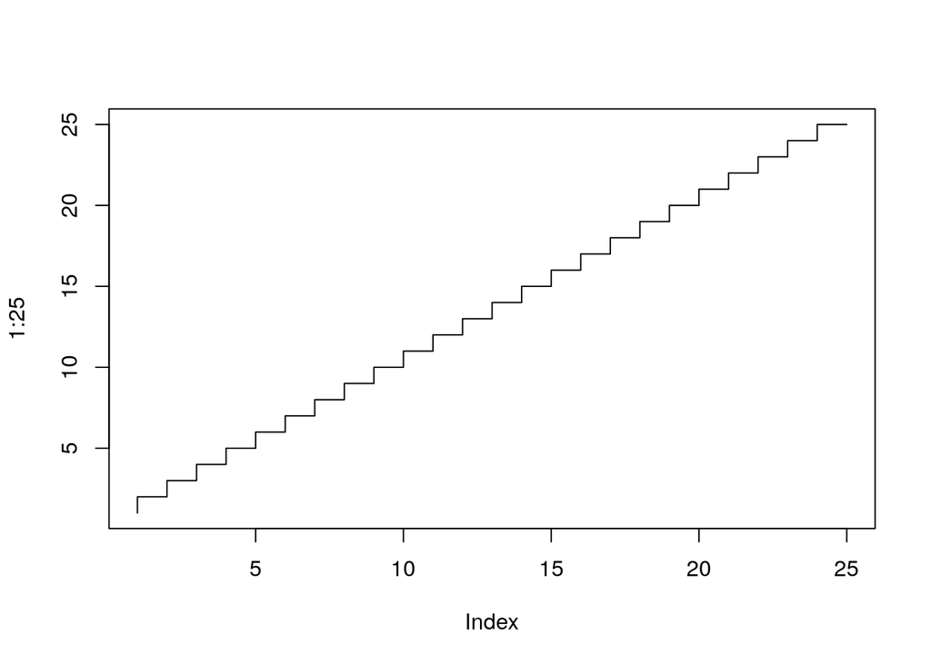

```r
plot(1:25, type = 'S')
```

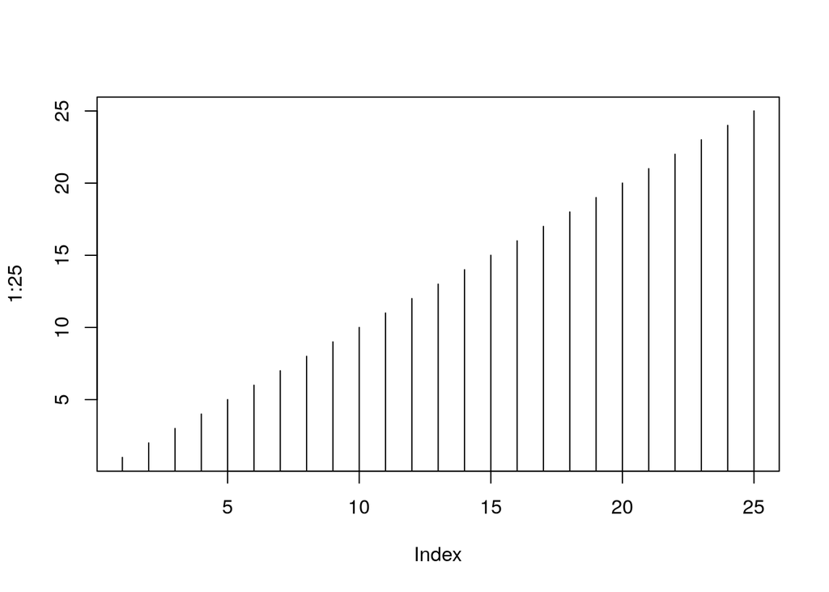

```r
plot(1:25, type = 'h')
```

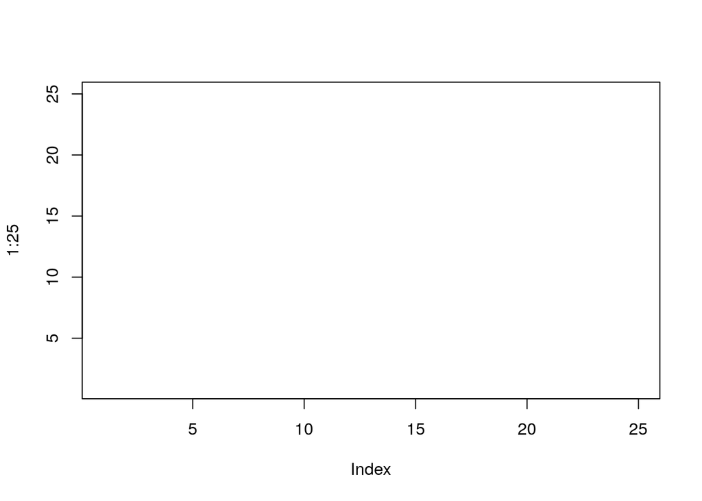

```r
plot(1:25, type = 'n')
```

## Markatzaileak

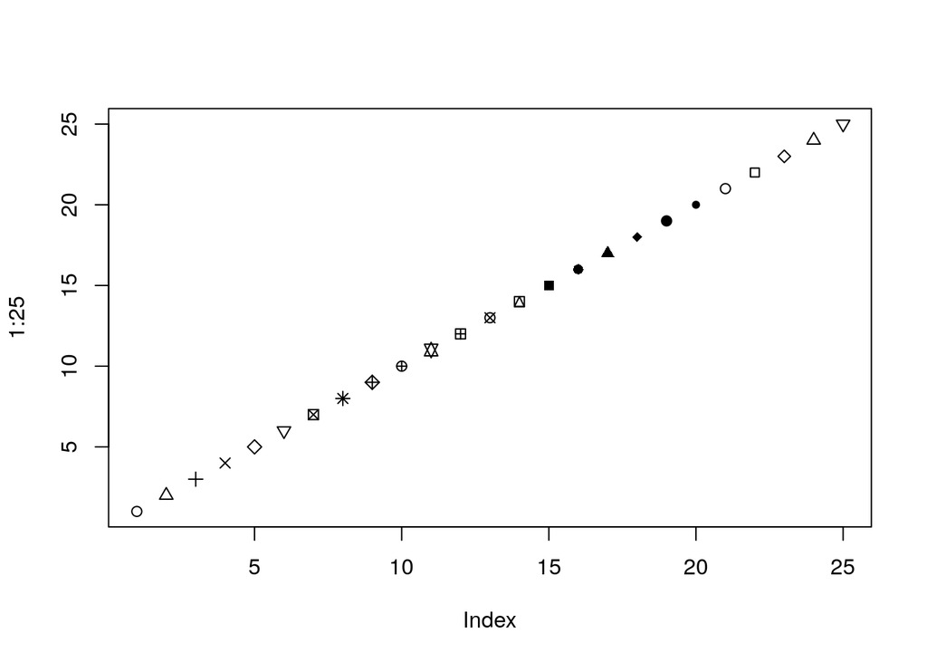

```r
plot(1:25,
     pch = 1:25)
```

Hurrengo aldaketak hobeto erakusteko, by default dakarrena baino nahiago dot beste sinbolo bat (biribil bete handia… 20.a dala emoten dauana… ia dan)

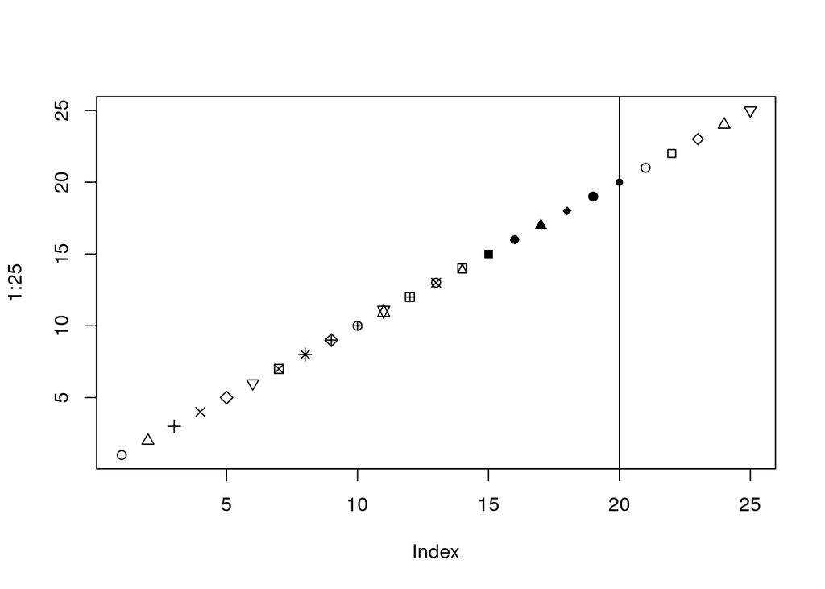

```r
plot(1:25,
     pch = 1:25)
abline(v = 20)
```

Punteria hobetu behar!

## Koloreak, `col =` aukera

### Oinarrizkoak

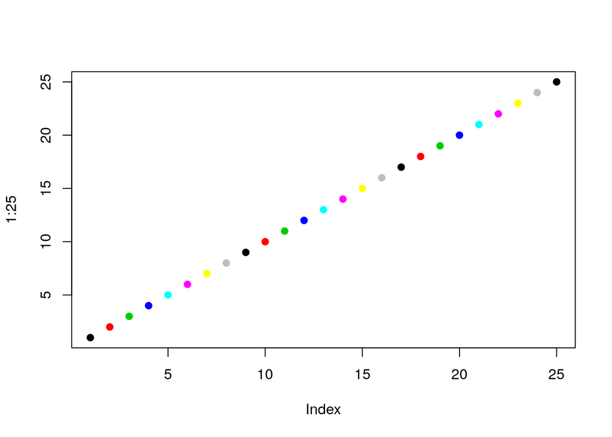

```r
plot(1:25,
     pch = 19,
     col = 1:25)
```

Ematen du 8tan errepikatu egiten dala, ia:

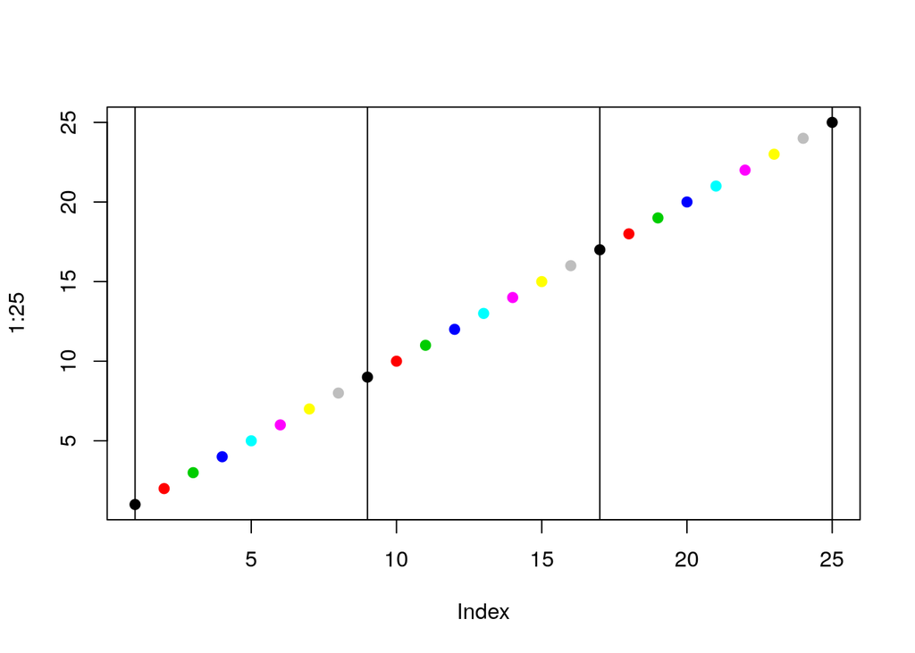

```r
plot(1:25,
     pch = 19,
     col = 1:25)
abline(v = c(1, 1+8, 1+8*2, 1+8*3))
```

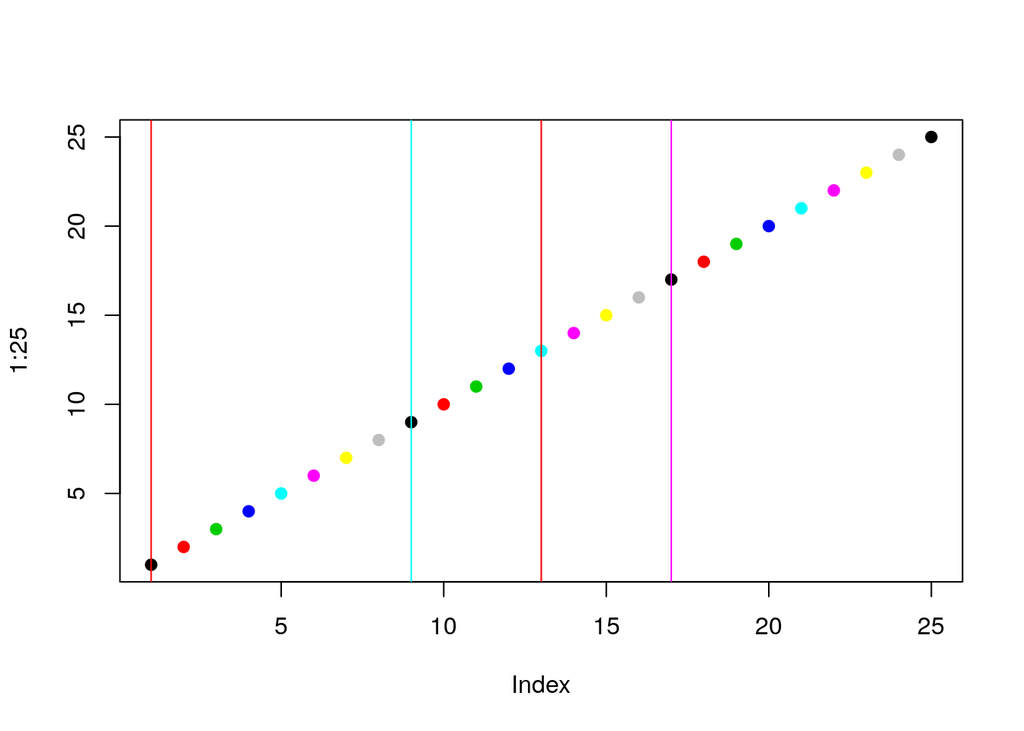

```r
plot(1:25,
     pch = 19,
     col = 1:25)
abline(v = c(1, 1+8, 1+8*2, 1+4*3), col = c(2,5,6))
```

**Ariketa**

Punteria egin behar duzu eta aurreko plot horretan hiru lerrok eman behar die hiru biribili **beren koloreaz**

### Beste batzuk

Koloreen izenak ezagutu ezkero, halan deitu ahal jake:

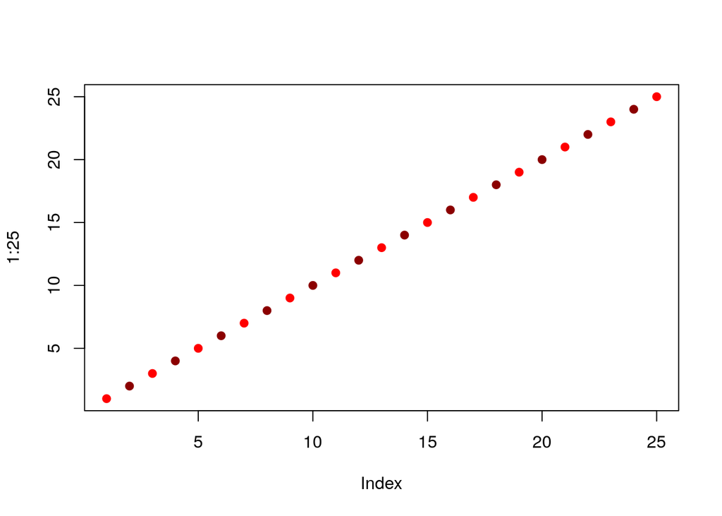

```r
plot(1:25,
     pch = 19,
     col = c('red',
             'darkred'))
```

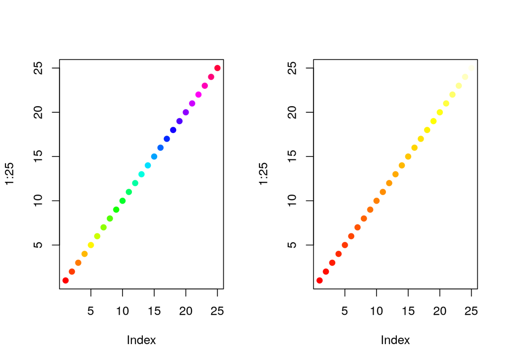

```r
par(mfrow = c(1, 2))
plot(1:25,
     pch = 19,
     col = rainbow(25))
plot(1:25,
     pch = 19,
     col = heat.colors(25))
```

```r
par(mfrow = c(1, 1))
```

Badira beste batzuk:

- `topo.colors`
- `grey.colors`
- Eremuka, norberak sortutakoak, gurdikada bat paleta…

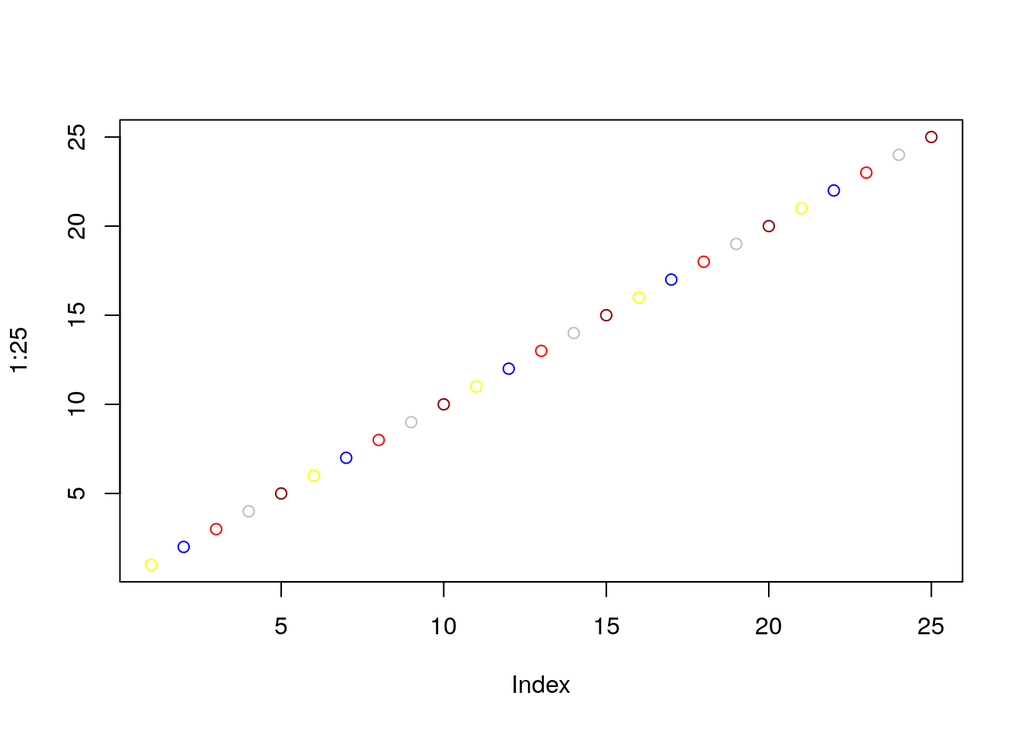

```r
paleta <- c('yellow', 'blue', 'red', 'grey', 'darkred')
plot(1:25, col = paleta)
```

## Tamainak

Honetarako biribil huts estandarra

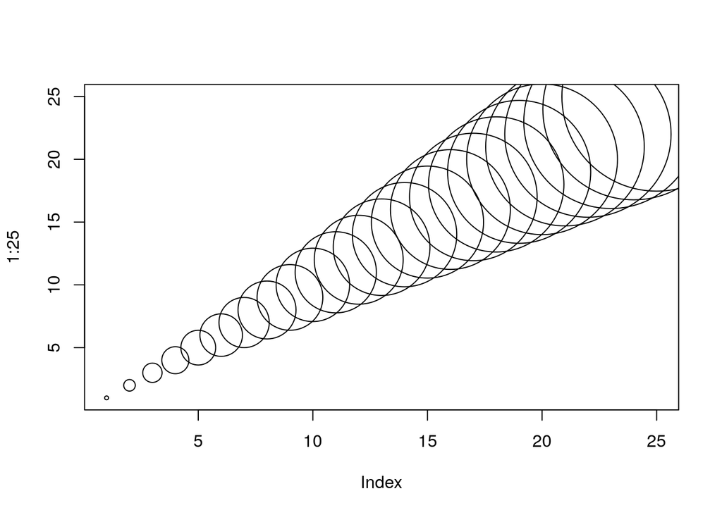

```r
plot(1:25,
     cex = 0.5:25)
```

# Gehitu zerbait

## Lerroak

Dagoaneko gehitu doguz batzuk, bakarrik *vertikalak* baina; `v` eman dogu-eta.

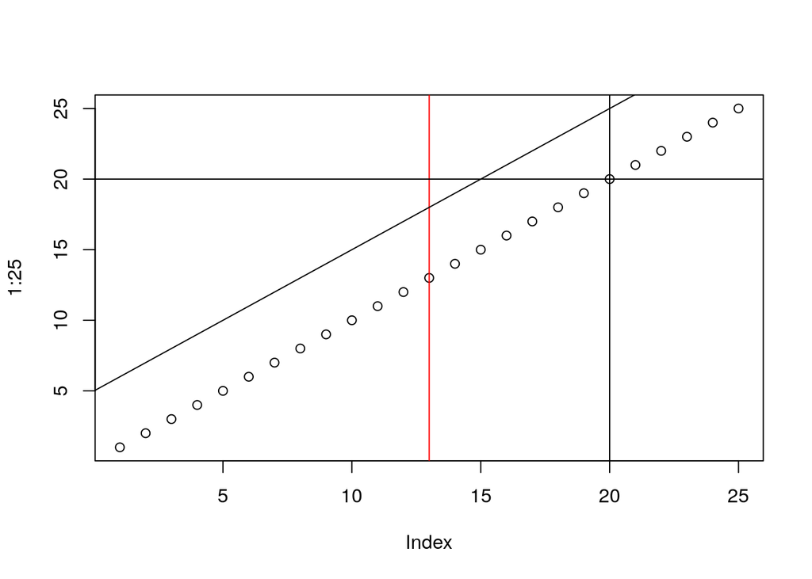

```r
plot(1:25)
abline(v = 20)
abline(v = mean(1:25), col =2)
abline(h = 20)
abline(a = 5, b = 1)
```

### Lodiera

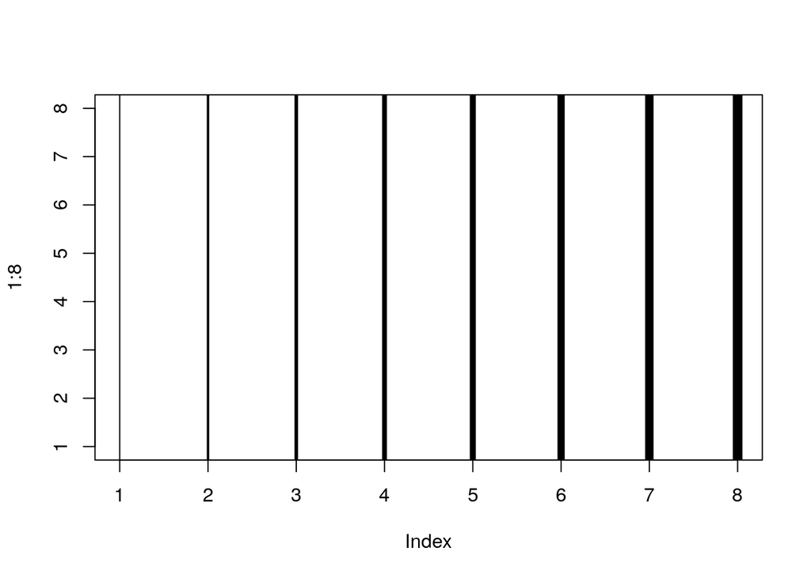

```r
## Marrak
plot(1:8, type = 'n')
abline(v = 1:8,
       lwd = 1:8)
```

### Motak

Lodiera handixeagoa hobeto ikusteko

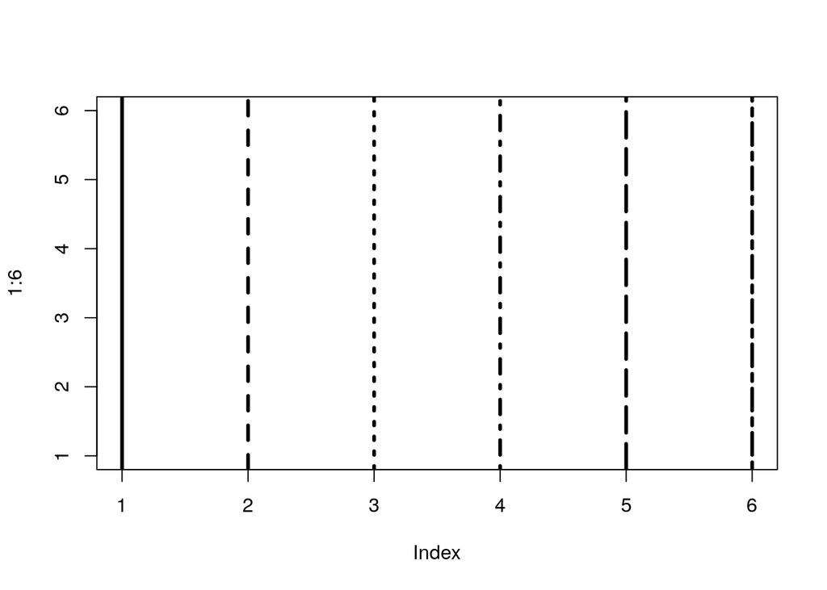

```r
## Marrak
plot(1:6, type = 'n')
abline(v = 1:6, lwd = 3,
       lty = 1:6)
```

## Segmentuak

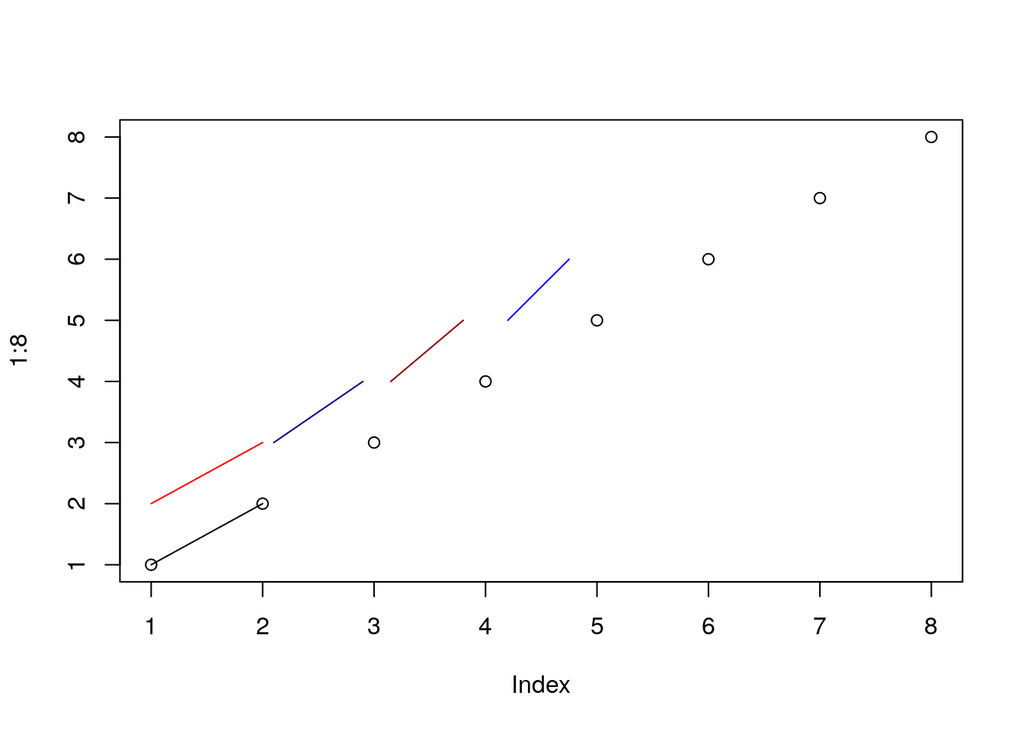

```r
plot(1:8)
lines(x = c(1, 2))
lines(x = c(1, 2), y = c(2, 3), col = 'red')
lines(x = c(2.1, 2.9), y = c(3, 4), col = 'darkblue')
lines(x = c(3.15, 3.8), y = c(4, 5), col = 'darkred')
lines(x = c(4.20, 4.75), y = c(5, 6), col = 'blue')
```

# Textua

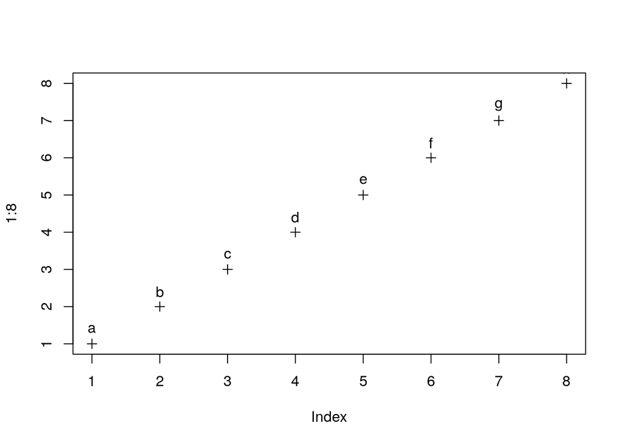

```r
plot(1:8, pch = 3)
text(x = 1:8+0.4, letters[1:8])
```

# Beste grafiko mota batzuk

## Pie

Dinoe hoba dala ez erabitzea, baina ondo etorri ahal zaigu zerbait ulertzeko bat edo batean

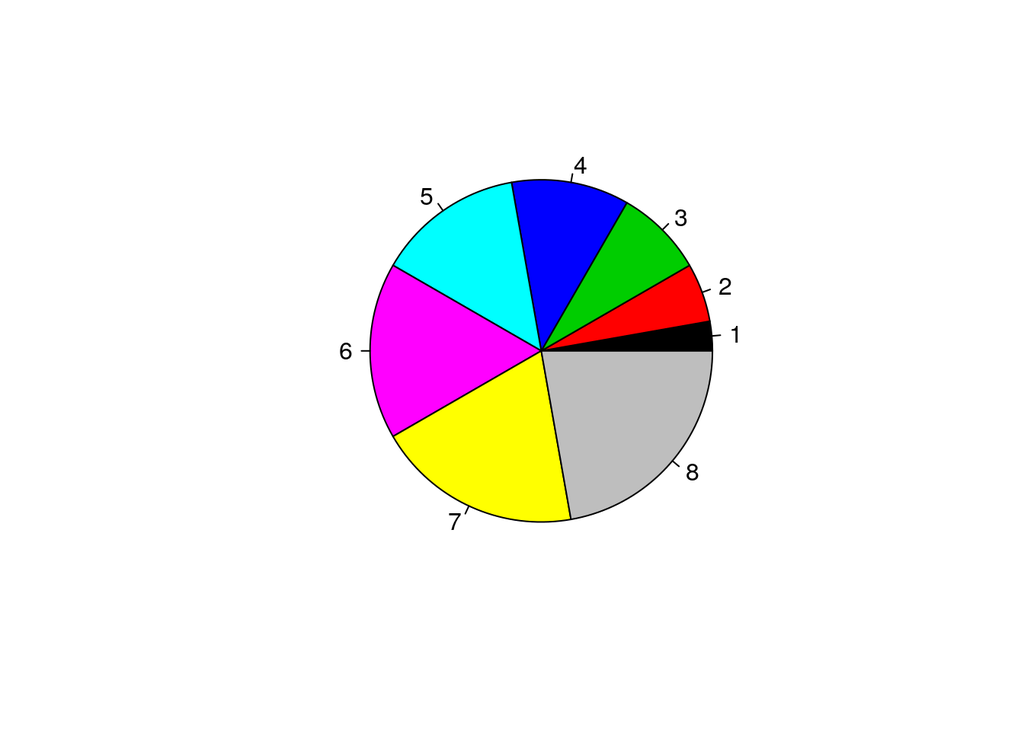

```r
pie(1:8, col = 1:8)
```

## Barra diagrama

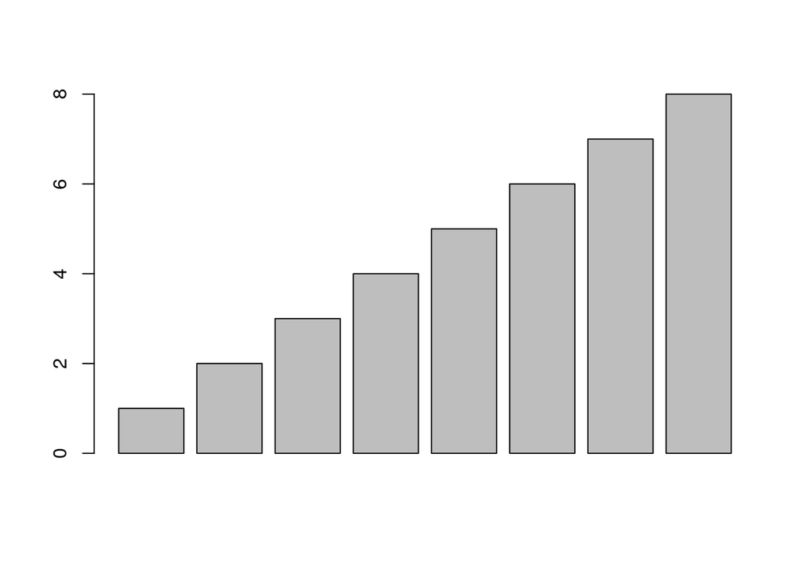

```r
barplot(1:8)
```

## Histogramea

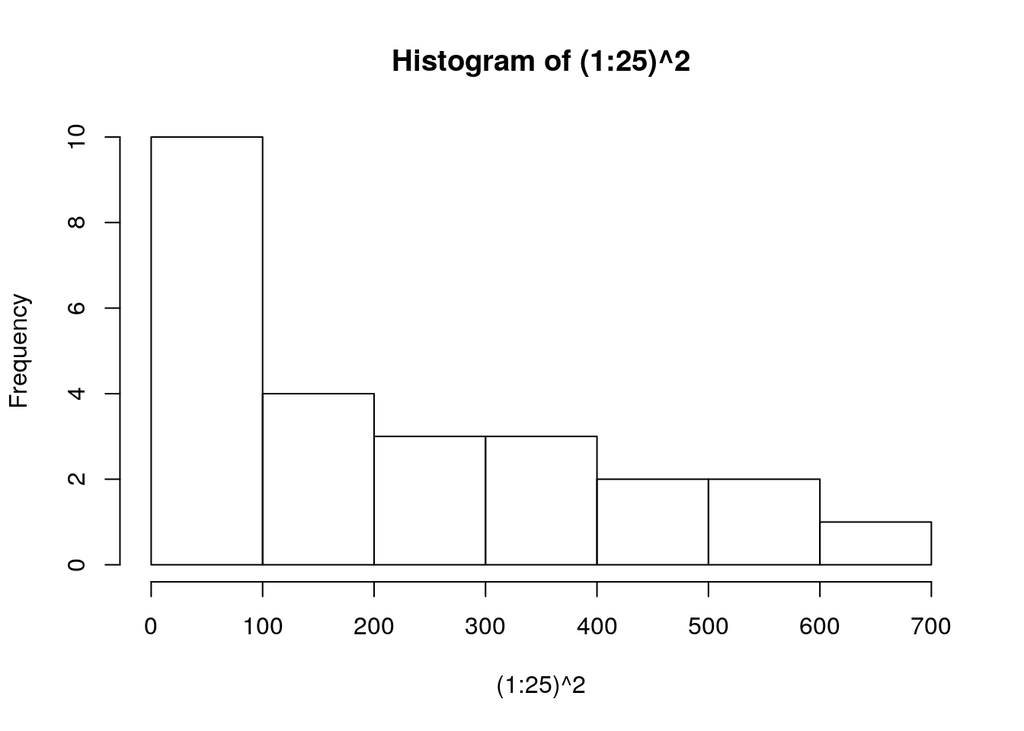

```r
hist((1:25)^2)
```

## Kaxa grafikoa

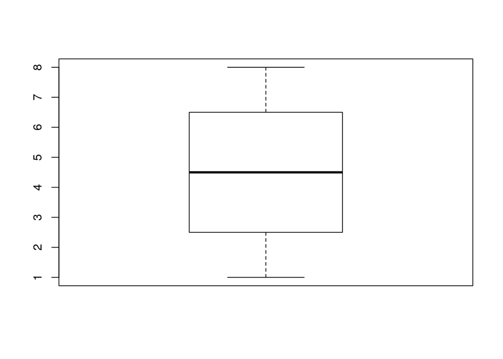

```r
boxplot(1:8)
```

## Mosaiko grafikoa

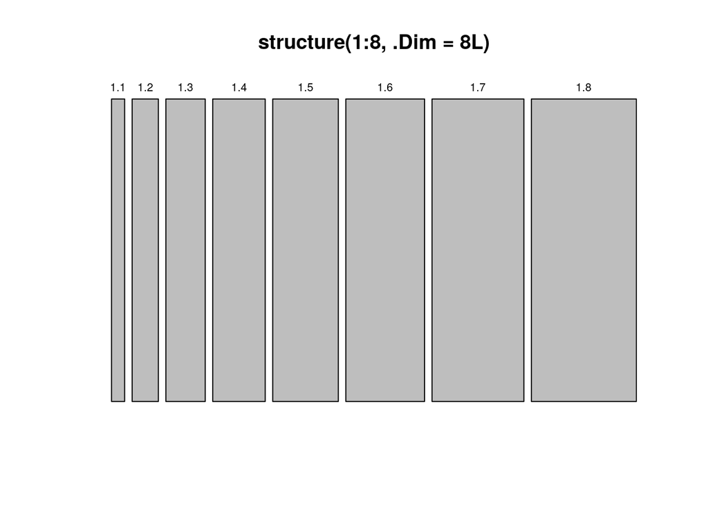

```r
mosaicplot(1:8)
```

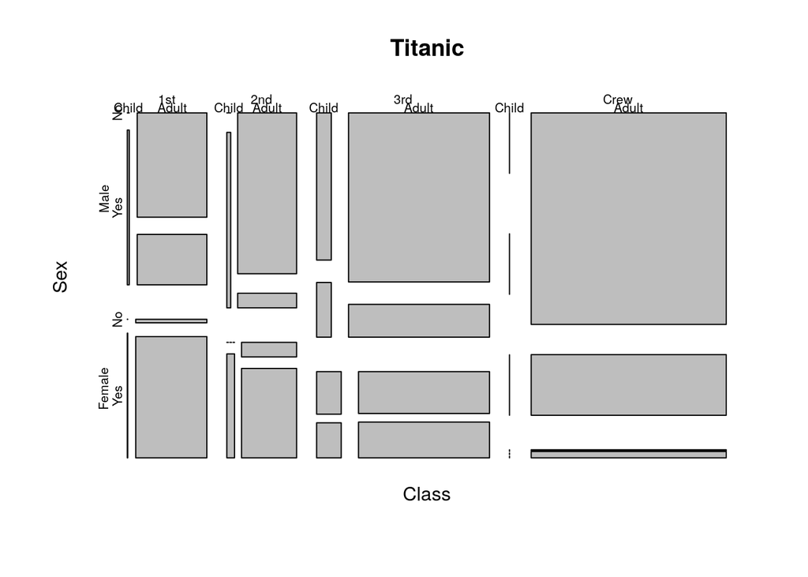

```r
data("Titanic")
mosaicplot(Titanic)
```

## Puntu diagrama

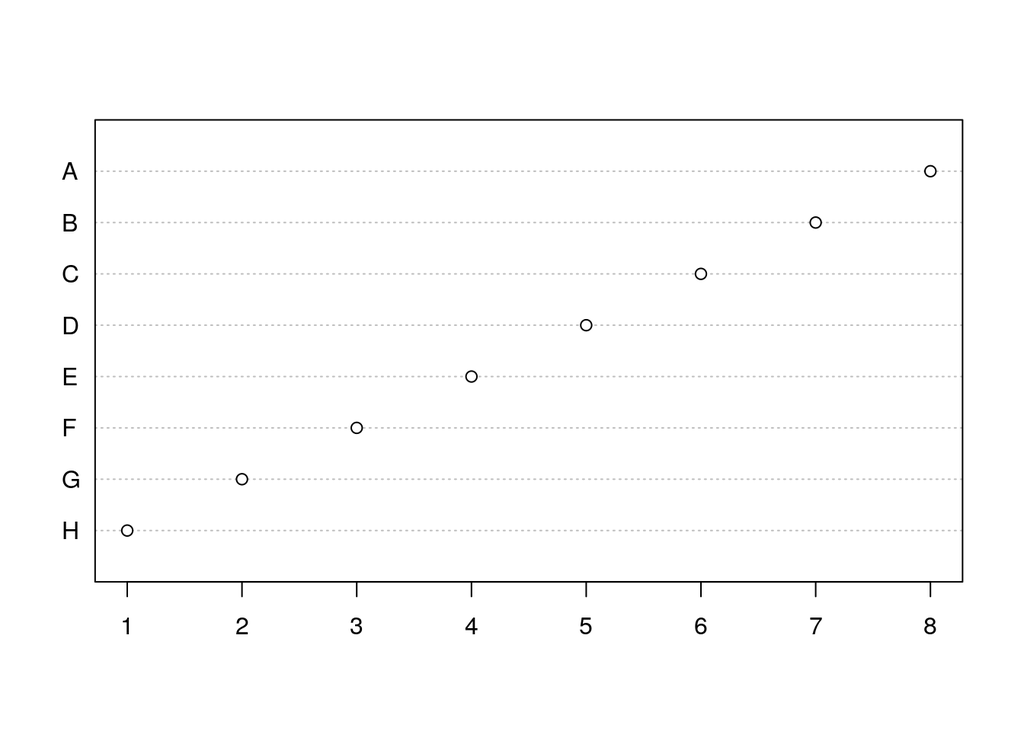

```r
dotchart(1:8, labels = LETTERS[8:1])
```